# Automobile Customer Segmentation

Import data set and read data set into data frame

```r
customers <- read.csv("C:/Users/Jacque de l'est/Documents/Datasets for Data Science/Automobile Company Customers.csv", stringsAsFactors = FALSE)
```

show data frame

```r
head(customers)
```

|  | ID | Gender | Ever_Married | Age | Graduated | Profession | Work_Experience | Spending_Score | Family_Size | Var_1 |
| --- | --- | --- | --- | --- | --- | --- | --- | --- | --- | --- |
| 1 | 458989 | Female | Yes | 36 | Yes | Engineer | 0 | Low | 1 | Cat_6 |
| 2 | 458994 | Male | Yes | 37 | Yes | Healthcare | 8 | Average | 4 | Cat_6 |
| 3 | 458996 | Female | Yes | 69 | No |  | 0 | Low | 1 | Cat_6 |
| 4 | 459000 | Male | Yes | 59 | No | Executive | 11 | High | 2 | Cat_6 |
| 5 | 459001 | Female | No | 19 | No | Marketing | NA | Low | 4 | Cat_6 |
| 6 | 459003 | Male | Yes | 47 | Yes | Doctor | 0 | High | 5 | Cat_4 |

Show data frame shape and columns

```r
str(customers)
```

```
'data.frame':   2627 obs. of  10 variables:
 $ ID             : int  458989 458994 458996 459000 459001 459003 459005 459008 459013 459014 ...
 $ Gender         : chr  "Female" "Male" "Female" "Male" ...
 $ Ever_Married   : chr  "Yes" "Yes" "Yes" "Yes" ...
 $ Age            : int  36 37 69 59 19 47 61 47 50 19 ...
 $ Graduated      : chr  "Yes" "Yes" "No" "No" ...
 $ Profession     : chr  "Engineer" "Healthcare" "" "Executive" ...
 $ Work_Experience: num  0 8 0 11 NA 0 5 1 2 0 ...
 $ Spending_Score : chr  "Low" "Average" "Low" "High" ...
 $ Family_Size    : num  1 4 1 2 4 5 3 3 4 4 ...
 $ Var_1          : chr  "Cat_6" "Cat_6" "Cat_6" "Cat_6" ...
```

show descriptive statistics of data set

```r
summary(customers)
```

```
       ID            Gender          Ever_Married            Age
 Min.   :458989   Length:2627        Length:2627        Min.   :18.00
 1st Qu.:461163   Class :character   Class :character   1st Qu.:30.00
 Median :463379   Mode  :character   Mode  :character   Median :41.00
 Mean   :463434                                         Mean   :43.65
 3rd Qu.:465696                                         3rd Qu.:53.00
 Max.   :467968                                         Max.   :89.00

  Graduated          Profession        Work_Experience  Spending_Score
 Length:2627        Length:2627        Min.   : 0.000   Length:2627
 Class :character   Class :character   1st Qu.: 0.000   Class :character
 Mode  :character   Mode  :character   Median : 1.000   Mode  :character
                                       Mean   : 2.553
                                       3rd Qu.: 4.000
                                       Max.   :14.000
                                       NA's   :269
  Family_Size       Var_1
 Min.   :1.000   Length:2627
 1st Qu.:2.000   Class :character
 Median :2.000   Mode  :character
 Mean   :2.825
 3rd Qu.:4.000
 Max.   :9.000
 NA's   :113
```

See missing values of data frame

```r
colSums(is.na(customers))
```

```
             ID          Gender    Ever_Married             Age       Graduated
              0               0               0               0               0
     Profession Work_Experience  Spending_Score     Family_Size           Var_1
              0             269               0             113               0
```

Fill missing values of Work_Experience with 0 and Family_Size with 1

```r
customers$Work_Experience[is.na(customers$Work_Experience)] <- 0
customers$Family_Size[is.na(customers$Family_Size)] <- 1
colSums(is.na(customers))
```

```
             ID          Gender    Ever_Married             Age       Graduated
              0               0               0               0               0
     Profession Work_Experience  Spending_Score     Family_Size           Var_1
              0               0               0               0               0
```

Check unique sum and values of data frame columns

```r
sapply(customers, function(x) length(unique(x)))
```

```
             ID          Gender    Ever_Married             Age       Graduated
           2627               2               3              67               3
     Profession Work_Experience  Spending_Score     Family_Size           Var_1
             10              15               3               9               8
```

```r
unique(customers$Gender)
```

```
[1] "Female" "Male"
```

```r
unique(customers$Ever_Married)
```

```
[1] "Yes" "No"  ""
```

```r
unique(customers$Graduated)
```

```
[1] "Yes" "No"  ""
```

```r
unique(customers$Profession)
```

```
 [1] "Engineer"      "Healthcare"    ""              "Executive"
 [5] "Marketing"     "Doctor"        "Artist"        "Lawyer"
 [9] "Entertainment" "Homemaker"
```

```r
unique(customers$Spending_Score)
```

```
[1] "Low"     "Average" "High"
```

```r
unique(customers$Var_1)
```

```
[1] "Cat_6" "Cat_4" "Cat_3" ""      "Cat_1" "Cat_2" "Cat_5" "Cat_7"
```

Show sum of empty values

```r
sum(customers$Ever_Married == "")
```

```
[1] 50
```

```r
sum(customers$Graduated == "")
```

```
[1] 24
```

```r
sum(customers$Profession == "")
```

```
[1] 38
```

```r
sum(customers$Var_1 == "")
```

```
[1] 32
```

Change empty values to NA values

```r
customers[customers == ""] <- NA
head(customers)
```

|  | ID | Gender | Ever_Married | Age | Graduated | Profession | Work_Experience | Spending_Score | Family_Size | Var_1 |
| --- | --- | --- | --- | --- | --- | --- | --- | --- | --- | --- |
| 1 | 458989 | Female | Yes | 36 | Yes | Engineer | 0 | Low | 1 | Cat_6 |
| 2 | 458994 | Male | Yes | 37 | Yes | Healthcare | 8 | Average | 4 | Cat_6 |
| 3 | 458996 | Female | Yes | 69 | No | NA | 0 | Low | 1 | Cat_6 |
| 4 | 459000 | Male | Yes | 59 | No | Executive | 11 | High | 2 | Cat_6 |
| 5 | 459001 | Female | No | 19 | No | Marketing | 0 | Low | 4 | Cat_6 |
| 6 | 459003 | Male | Yes | 47 | Yes | Doctor | 0 | High | 5 | Cat_4 |

Fill NA values with proper values

```r
customers$Ever_Married[is.na(customers$Ever_Married)] <- "No"
customers$Graduated[is.na(customers$Graduated)] <- "No"
customers$Profession[is.na(customers$Profession)] <- "others"
customers$Var_1[is.na(customers$Var_1)] <- "Cat_0"
sum(is.na(customers))
```

```
[1] 0
```

Show distribution of categorical data

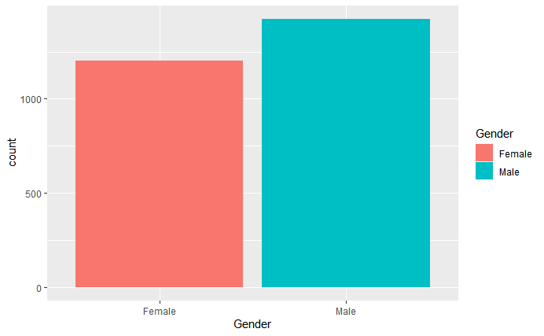

```r
library(ggplot2)
ggplot(customers, aes(x = Gender, fill = Gender)) + geom_bar()
```

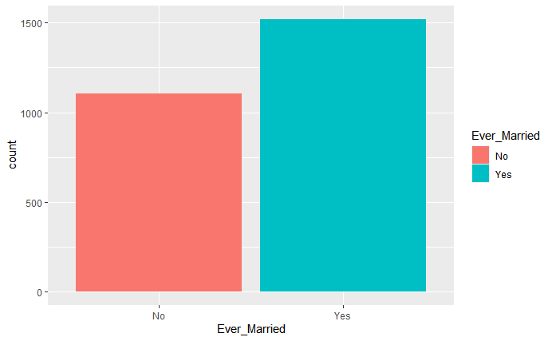

```r
ggplot(customers, aes(x = Ever_Married, fill = Ever_Married)) + geom_bar()
```

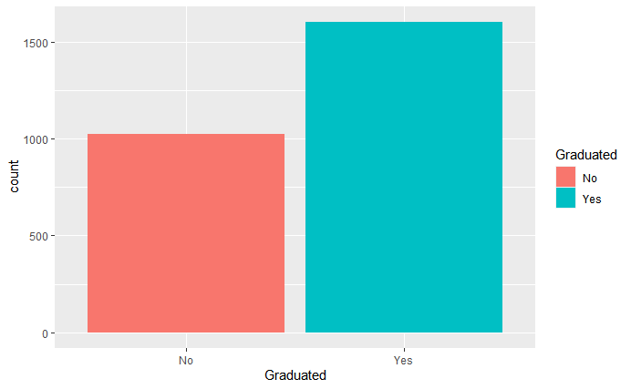

```r
ggplot(customers, aes(x = Graduated, fill = Graduated)) + geom_bar()
```

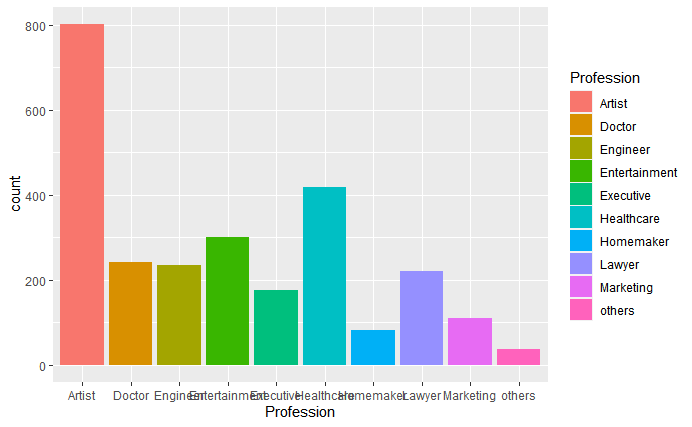

```r
ggplot(customers, aes(x = Profession, fill = Profession)) + geom_bar()
```

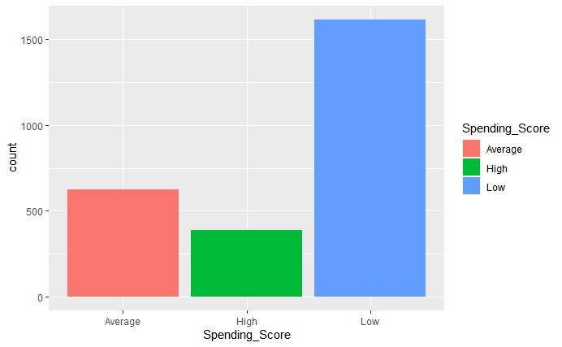

```r
ggplot(customers, aes(x = Spending_Score, fill = Spending_Score)) + geom_bar()
```

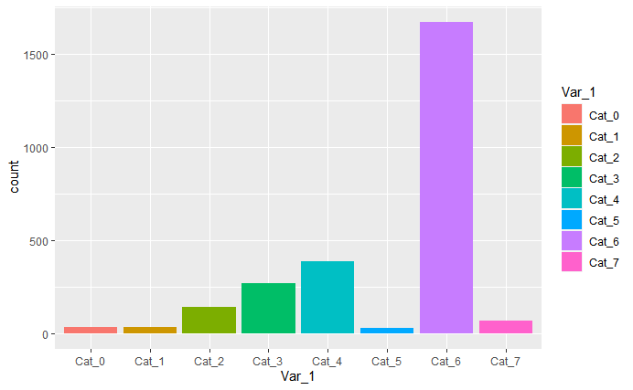

```r
ggplot(customers, aes(x = Var_1, fill = Var_1)) + geom_bar()
```

Show distribution of numerical columns

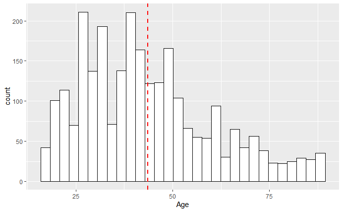

```r
# Distribution of Age
#histogram & mean line
ggplot(customers, aes(x=Age, fill=Age)) +
    geom_histogram(color = "black", fill = "white") + geom_vline(aes(xintercept=mean(Age)),
               color="red", linetype="dashed", size=1)
```

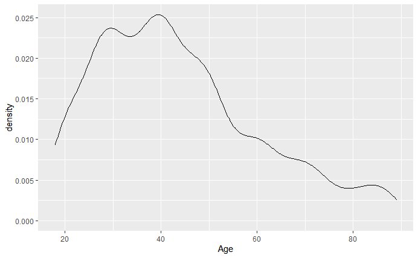

```r
#density curve
ggplot(customers, aes(x=Age)) + geom_density()
```

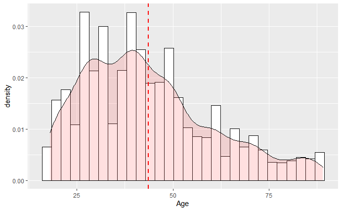

```r
#histogram and mean line overlaid with kernel density curve
ggplot(customers, aes(x=Age)) +
    geom_histogram(aes(y=..density..),
                   colour="black", fill="white") +
    geom_density(alpha=0.2, fill="#FF6666") + geom_vline(aes(xintercept=mean(Age)),
               color="red", linetype="dashed", size=1)
```

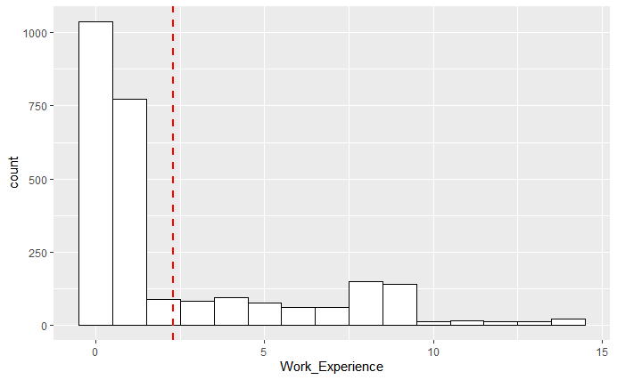

```r
# Distribution of Work Experience
#histogram & mean line
ggplot(customers, aes(x=Work_Experience, fill=Work_Experience)) +
    geom_histogram(binwidth = 1, color = "black", fill = "white") + geom_vline(aes(xintercept=mean(Work_Experience)),
               color="red", linetype="dashed", size=1)
```

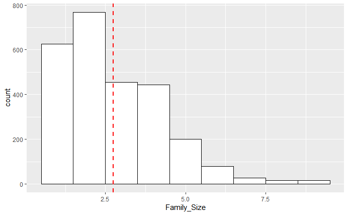

```r
# Distribution of Family Size
#histogram & mean line
ggplot(customers, aes(x=Family_Size, fill=Family_Size)) +
    geom_histogram(binwidth = 1, color = "black", fill = "white") + geom_vline(aes(xintercept=mean(Family_Size)),
               color="red", linetype="dashed", size=1)
```

Drop column ID

```r
customers_new <- customers[-1]
head(customers_new)
```

|  | Gender | Ever_Married | Age | Graduated | Profession | Work_Experience | Spending_Score | Family_Size | Var_1 |
| --- | --- | --- | --- | --- | --- | --- | --- | --- | --- |
| 1 | Female | Yes | 36 | Yes | Engineer | 0 | Low | 1 | Cat_6 |
| 2 | Male | Yes | 37 | Yes | Healthcare | 8 | Average | 4 | Cat_6 |
| 3 | Female | Yes | 69 | No | others | 0 | Low | 1 | Cat_6 |
| 4 | Male | Yes | 59 | No | Executive | 11 | High | 2 | Cat_6 |
| 5 | Female | No | 19 | No | Marketing | 0 | Low | 4 | Cat_6 |
| 6 | Male | Yes | 47 | Yes | Doctor | 0 | High | 5 | Cat_4 |

Convert categorical columns to numerical columns

```r
cat_columns <- data.matrix(customers_new[c("Gender","Ever_Married","Graduated","Profession","Spending_Score","Var_1")])
head(cat_columns)
```

```
     Gender Ever_Married Graduated Profession Spending_Score Var_1
[1,]      1            2         2          3              3     7
[2,]      2            2         2          6              1     7
[3,]      1            2         1         10              3     7
[4,]      2            2         1          5              2     7
[5,]      1            1         1          9              3     7
[6,]      2            2         2          2              2     5
```

Merge converted categorical columns with original data frame

```r
customers <- data.frame(customers, cat_columns)
head(customers)
```

|  | ID | Gender | Ever_Married | Age | Graduated | Profession | Work_Experience | Spending_Score | Family_Size | Var_1 | Gender.1 | Ever_Married.1 | Graduated.1 | Profession.1 | Spending_Score.1 | Var_1.1 |
| --- | --- | --- | --- | --- | --- | --- | --- | --- | --- | --- | --- | --- | --- | --- | --- | --- |
| 1 | 458989 | Female | Yes | 36 | Yes | Engineer | 0 | Low | 1 | Cat_6 | 1 | 2 | 2 | 3 | 3 | 7 |
| 2 | 458994 | Male | Yes | 37 | Yes | Healthcare | 8 | Average | 4 | Cat_6 | 2 | 2 | 2 | 6 | 1 | 7 |
| 3 | 458996 | Female | Yes | 69 | No | others | 0 | Low | 1 | Cat_6 | 1 | 2 | 1 | 10 | 3 | 7 |
| 4 | 459000 | Male | Yes | 59 | No | Executive | 11 | High | 2 | Cat_6 | 2 | 2 | 1 | 5 | 2 | 7 |
| 5 | 459001 | Female | No | 19 | No | Marketing | 0 | Low | 4 | Cat_6 | 1 | 1 | 1 | 9 | 3 | 7 |
| 6 | 459003 | Male | Yes | 47 | Yes | Doctor | 0 | High | 5 | Cat_4 | 2 | 2 | 2 | 2 | 2 | 5 |

Create data master from categorical and converted categorical columns

```r
Gender <- unique(customers[c('Gender','Gender.1')])
Ever_Married <- unique(customers[c('Ever_Married','Ever_Married.1')])
Graduated <- unique(customers[c('Graduated', 'Graduated.1')])
Profession <- unique(customers[c('Profession','Profession.1')])
Spending_Score <- unique(customers[c('Spending_Score','Spending_Score.1')])
Var_1 <- unique(customers[c('Var_1','Var_1.1')])
```

Create a variable for clustering with k-means

```r
used_data <- c('Gender.1','Ever_Married.1','Age','Graduated.1','Profession.1','Work_Experience','Spending_Score.1','Family_Size','Var_1.1')
```

Look for optimal cluster for k-means clustering

```r
set.seed(100)
sse <- sapply(1:10,
              function(param_k)
              {kmeans(customers[used_data], param_k, nstart=25)$tot.withinss}
             )
print(sse)
```

```
 [1] 818717.80 304615.78 167229.26 119708.15  96460.12  82815.75  72984.20
 [8]  64737.08  57732.85  54871.66
```

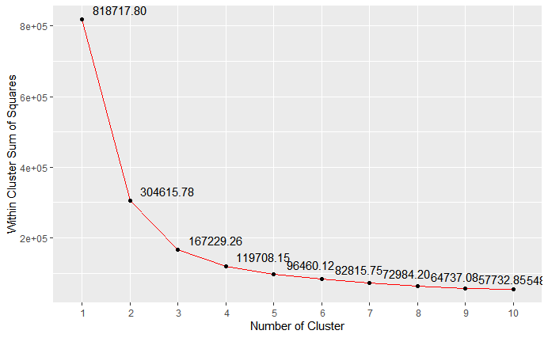

```r
#graphic elbow effect
max_cluster <- 10
ssdata = data.frame(cluster=c(1:max_cluster),sse)
ggplot(ssdata, aes(x=cluster,y=sse)) +
                geom_line(color="red") + geom_point() +
                ylab("Within Cluster Sum of Squares") + xlab("Number of Cluster") +
                geom_text(aes(label=format(round(sse, 2), nsmall = 2)),hjust=-0.2, vjust=-0.5) +
  scale_x_discrete(limits=c(1:max_cluster))
```

Cluster with k-means

```r
#k-means function creates 5 clusters with 25 random scenarios and saves them into segmentation
set.seed(100)
segmentation <- kmeans(x = customers[used_data], centers = 5, nstart = 25)
segmentation
```

```
K-means clustering with 5 clusters of sizes 357, 773, 753, 559, 185

Cluster means:
  Gender.1 Ever_Married.1      Age Graduated.1 Profession.1 Work_Experience
1 1.605042       1.929972 64.62745    1.705882     3.831933       1.2885154
2 1.495472       1.557568 38.15783    1.710220     3.097025       3.2703752
3 1.560425       1.162019 25.46614    1.350598     4.804781       2.4594954
4 1.550984       1.822898 49.81753    1.774597     2.851521       1.8139535
5 1.513514       1.945946 81.49189    1.562162     7.205405       0.8918919
  Spending_Score.1 Family_Size  Var_1.1
1         2.030812    2.406162 6.372549
2         2.350582    2.520052 5.996119
3         2.851262    3.382470 5.770252
4         1.992844    2.728086 6.178891
5         2.389189    1.821622 6.583784
```

[output cut: 39 more lines]

Merge clustering result into data frame customers

```r
customers$Cluster <- segmentation$cluster
str(customers)
```

```
'data.frame':   2627 obs. of  17 variables:
 $ ID              : int  458989 458994 458996 459000 459001 459003 459005 459008 459013 459014 ...
 $ Gender          : chr  "Female" "Male" "Female" "Male" ...
 $ Ever_Married    : chr  "Yes" "Yes" "Yes" "Yes" ...
 $ Age             : int  36 37 69 59 19 47 61 47 50 19 ...
 $ Graduated       : chr  "Yes" "Yes" "No" "No" ...
 $ Profession      : chr  "Engineer" "Healthcare" "others" "Executive" ...
 $ Work_Experience : num  0 8 0 11 0 0 5 1 2 0 ...
 $ Spending_Score  : chr  "Low" "Average" "Low" "High" ...
 $ Family_Size     : num  1 4 1 2 4 5 3 3 4 4 ...
 $ Var_1           : chr  "Cat_6" "Cat_6" "Cat_6" "Cat_6" ...
 $ Gender.1        : int  1 2 1 2 1 2 2 1 2 2 ...
 $ Ever_Married.1  : int  2 2 2 2 1 2 2 2 2 1 ...
 $ Graduated.1     : int  2 2 1 1 1 2 2 2 2 1 ...
 $ Profession.1    : int  3 6 10 5 9 2 2 1 1 6 ...
 $ Spending_Score.1: int  3 1 3 2 3 2 3 1 1 3 ...
 $ Var_1.1         : int  7 7 7 7 7 5 7 7 7 7 ...
 $ Cluster         : int  2 2 1 1 3 4 1 4 4 3 ...
```

Check clustering result

```r
head(which(customers$Cluster == 1))
```

```
[1]  3  4  7 16 21 22
```

```r
length(which(customers$Cluster == 1))
```

```
[1] 357
```

```r
segmentation$ifault
```

```
[1] 0
```

```r
customers[which(customers$Cluster == 1),]
```

|  | ID | Gender | Ever_Married | Age | Graduated | Profession | Work_Experience | Spending_Score | Family_Size | Var_1 | Gender.1 | Ever_Married.1 | Graduated.1 | Profession.1 | Spending_Score.1 | Var_1.1 | Cluster |
| --- | --- | --- | --- | --- | --- | --- | --- | --- | --- | --- | --- | --- | --- | --- | --- | --- | --- |
| 3 | 458996 | Female | Yes | 69 | No | others | 0 | Low | 1 | Cat_6 | 1 | 2 | 1 | 10 | 3 | 7 | 1 |
| 4 | 459000 | Male | Yes | 59 | No | Executive | 11 | High | 2 | Cat_6 | 2 | 2 | 1 | 5 | 2 | 7 | 1 |
| 7 | 459005 | Male | Yes | 61 | Yes | Doctor | 5 | Low | 3 | Cat_6 | 2 | 2 | 2 | 2 | 3 | 7 | 1 |
| 16 | 459033 | Female | Yes | 61 | Yes | Artist | 0 | Low | 1 | Cat_6 | 1 | 2 | 2 | 1 | 3 | 7 | 1 |
| 21 | 459056 | Male | Yes | 63 | No | Executive | 0 | High | 3 | Cat_6 | 2 | 2 | 1 | 5 | 2 | 7 | 1 |
| 22 | 459057 | Male | Yes | 69 | No | Lawyer | 0 | High | 1 | Cat_6 | 2 | 2 | 1 | 8 | 2 | 7 | 1 |
| 32 | 459083 | Male | Yes | 63 | Yes | Artist | 9 | Average | 3 | Cat_0 | 2 | 2 | 2 | 1 | 1 | 1 | 1 |
| 34 | 459091 | Male | Yes | 72 | Yes | Artist | 1 | Average | 6 | Cat_1 | 2 | 2 | 2 | 1 | 1 | 2 | 1 |
| 36 | 459100 | Female | No | 61 | Yes | Artist | 11 | Low | 1 | Cat_6 | 1 | 1 | 2 | 1 | 3 | 7 | 1 |
| 37 | 459106 | Male | Yes | 62 | Yes | Artist | 0 | Low | 2 | Cat_6 | 2 | 2 | 2 | 1 | 3 | 7 | 1 |

[output cut: 347 more lines]

Name the segmentation

```r
CustomerSegmentation <- data.frame(Cluster = c(1,2,3,4,5), Segmentation = c("Diamond Senior", "Silver Middle", "Silver Young", "Gold Professional", "Diamond Professional"))
```

Combine the references and save to file

```r
ClusterID <- list(Gender = Gender, Ever_Married = Ever_Married, Graduated = Graduated, Profession = Profession, Spending_Score = Spending_Score, Var_1 = Var_1, segmentation = segmentation, CustomerSegmentation = CustomerSegmentation, used_data = used_data)
saveRDS(ClusterID, "Cluster ID.rds")
```

Load Cluster Identity from file

```r
Cluster.ID <- readRDS(file = 'Cluster ID.rds')
Cluster.ID
```

|  | Gender | Gender.1 |
| --- | --- | --- |
| 1 | Female | 1 |
| 2 | Male | 2 |

|  | Ever_Married | Ever_Married.1 |
| --- | --- | --- |
| 1 | Yes | 2 |
| 5 | No | 1 |

|  | Graduated | Graduated.1 |
| --- | --- | --- |
| 1 | Yes | 2 |
| 3 | No | 1 |

|  | Profession | Profession.1 |
| --- | --- | --- |
| 1 | Engineer | 3 |
| 2 | Healthcare | 6 |
| 3 | others | 10 |
| 4 | Executive | 5 |
| 5 | Marketing | 9 |
| 6 | Doctor | 2 |
| 8 | Artist | 1 |
| 17 | Lawyer | 8 |
| 47 | Entertainment | 4 |
| 91 | Homemaker | 7 |

|  | Spending_Score | Spending_Score.1 |
| --- | --- | --- |
| 1 | Low | 3 |
| 2 | Average | 1 |
| 4 | High | 2 |

|  | Var_1 | Var_1.1 |
| --- | --- | --- |
| 1 | Cat_6 | 7 |
| 6 | Cat_4 | 5 |
| 14 | Cat_3 | 4 |
| 32 | Cat_0 | 1 |
| 34 | Cat_1 | 2 |
| 43 | Cat_2 | 3 |
| 58 | Cat_5 | 6 |
| 127 | Cat_7 | 8 |

```
$segmentation
K-means clustering with 5 clusters of sizes 357, 773, 753, 559, 185

Cluster means:
  Gender.1 Ever_Married.1      Age Graduated.1 Profession.1 Work_Experience
1 1.605042       1.929972 64.62745    1.705882     3.831933       1.2885154
2 1.495472       1.557568 38.15783    1.710220     3.097025       3.2703752
3 1.560425       1.162019 25.46614    1.350598     4.804781       2.4594954
4 1.550984       1.822898 49.81753    1.774597     2.851521       1.8139535
5 1.513514       1.945946 81.49189    1.562162     7.205405       0.8918919
  Spending_Score.1 Family_Size  Var_1.1
1         2.030812    2.406162 6.372549
2         2.350582    2.520052 5.996119
3         2.851262    3.382470 5.770252
4         1.992844    2.728086 6.178891
```

[output cut: 42 more lines]

| Cluster | Segmentation |
| --- | --- |
| 1 | Diamond Senior |
| 2 | Silver Middle |
| 3 | Silver Young |
| 4 | Gold Professional |
| 5 | Diamond Professional |

```
$used_data
[1] "Gender.1"         "Ever_Married.1"   "Age"              "Graduated.1"
[5] "Profession.1"     "Work_Experience"  "Spending_Score.1" "Family_Size"
[9] "Var_1.1"
```

Test clustering with new data

```r
#create new data
new_data <- data.frame(ID = '257157', Gender = 'Male', Ever_Married = 'No', Age = 34, Graduated = 'Yes', Profession = 'Artist', Work_Experience = 6, Spending_Score = 'Low', Family_Size = 1, Var_1 = 'Cat_2')

#merge new data with data from Cluster Identity
new_data <- merge(new_data, Cluster.ID$Gender)
new_data <- merge(new_data, Cluster.ID$Ever_Married)
new_data <- merge(new_data, Cluster.ID$Graduated)
new_data <- merge(new_data, Cluster.ID$Profession)
new_data <- merge(new_data, Cluster.ID$Spending_Score)
new_data <- merge(new_data, Cluster.ID$Var_1)
new_data
```

| Var_1 | Spending_Score | Profession | Graduated | Ever_Married | Gender | ID | Age | Work_Experience | Family_Size | Gender.1 | Ever_Married.1 | Graduated.1 | Profession.1 | Spending_Score.1 | Var_1.1 |
| --- | --- | --- | --- | --- | --- | --- | --- | --- | --- | --- | --- | --- | --- | --- | --- |
| Cat_2 | Low | Artist | Yes | No | Male | 257157 | 34 | 6 | 1 | 2 | 1 | 2 | 1 | 3 | 3 |

```r
#clustering new data
Cluster.ID$CustomerSegmentation[which.min(sapply(1:5, function(x) sum((new_data[Cluster.ID$used_data] - Cluster.ID$segmentation$centers[x,])^2))),]
```

|  | Cluster | Segmentation |
| --- | --- | --- |
| 2 | 2 | Silver Middle |